# Análisis de varianza y repaso

César Alcívar

29/12/2021

# 1 Introducción

Este conjunto de datos contiene información de una muestra extraída a partir de un censo, en el que para cada persona, se registran los salarios aparte de información personal adicional. El conjunto de datos contiene 32.560 registros y 9 variables.

Las variables de esta muestra son:

- Age: Edad del individuo.
- Workclass: Categorización del individuo en base al perfil laboral.
- Education_num: Número de años de formación educativa del individuo.
- Marital_status: Estado civil del individuo.
- Occupation: Categorización del individuo en base a la tipología de trabajo.
- Race: Grupo racial al que pertenece el individuo.
- Sex: Género del individuo.
- hours_per_week: Horas por semana trabajadas por el individuo.
- income: Salario (anual) del individuo, en k€.

# 2 Lectura del archivo y preparación de los datos

Se carga el dataset en una variable llamada `adult`.

```r
adult = read.table('../R/data/CensusIncomedata.txt', header = T, stringsAsFactors = T)
dim(adult)
```

```
## [1] 32560     9
```

Se verifica que el dataset tiene 32.560 registros y 9 variables.

## 2.1 Preparación de los datos

A continuación, se eliminan los espacios en blancos de los campos de tipo carácter.

```r
fields <- c("workclass", "marital_status", "occupation", "race", "sex")

for (field in fields) {
  adult[, field] <- factor(trimws(adult[,field]))
}
```

Se cambia el nombre de la columna `sex` por `gender`.

```r
colnames(adult)[7] <- "gender"
names(adult)
```

```
## [1] "age"            "workclass"      "education_num"  "marital_status"
## [5] "occupation"     "race"           "gender"         "hours_per_week"
## [9] "income"
```

*¿Qué podemos afirmar sobre la normalidad de la variable salario?

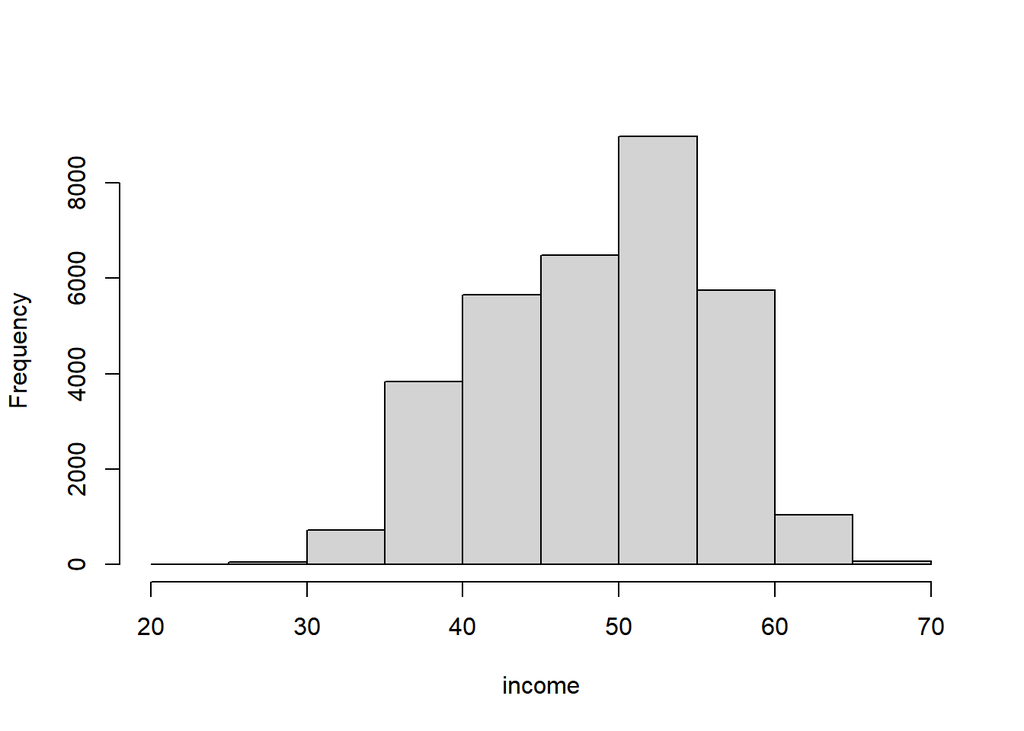

```r
hist(adult$income, main = "", xlab = "income")
```

```r
if(!require("nortest")) install.packages("nortest")
library(nortest)

shapiro.test(adult$income[0:5000])
```

```
##
##  Shapiro-Wilk normality test
##
## data:  adult$income[0:5000]
## W = 0.98142, p-value < 2.2e-16
```

Se codifica la variable ‘Less50‘ con el valor 1 cuando el salario sea inferior a 50k€, e igual a 0 en caso contrario.

```r
adult$Less50 <- ifelse(adult$income < 50, 1, 0)
```

## 2.2 Análisis visual

### 2.2.1 Muestra con varios diagramas de caja la distribución de la variable income según las variables gender, race, workclass, marital_status y occupation.

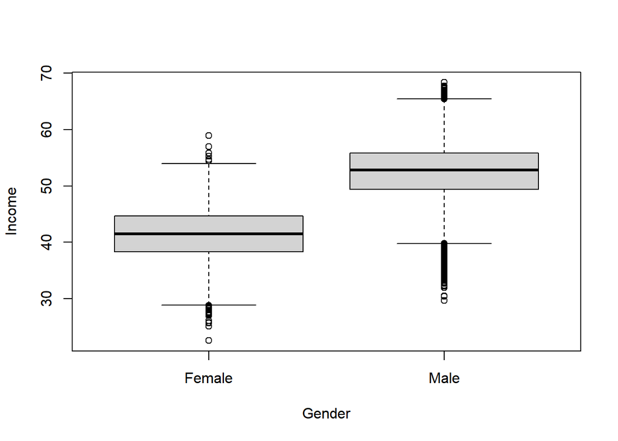

```r
boxplot(adult$income~adult$gender, ylab = "Income", xlab = "Gender")
```

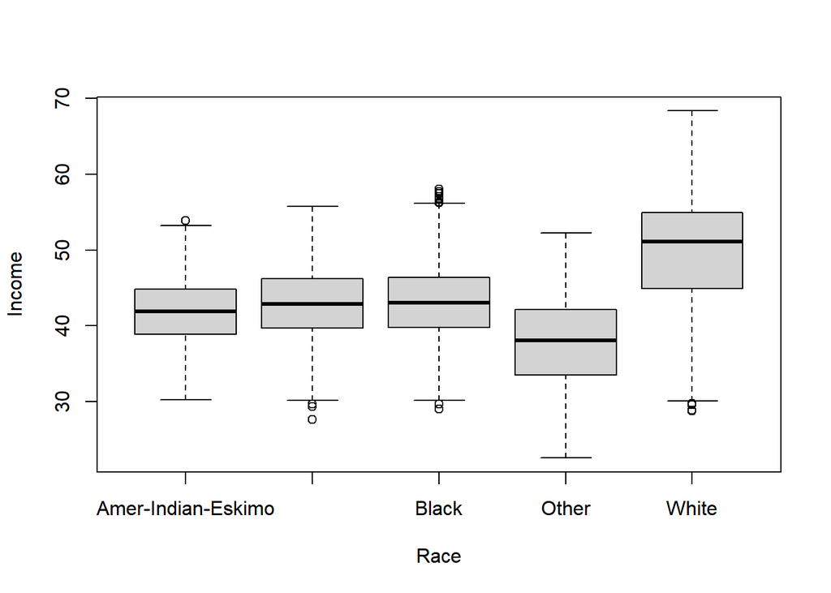

```r
boxplot(adult$income~adult$race, ylab = "Income", xlab = "Race")
```

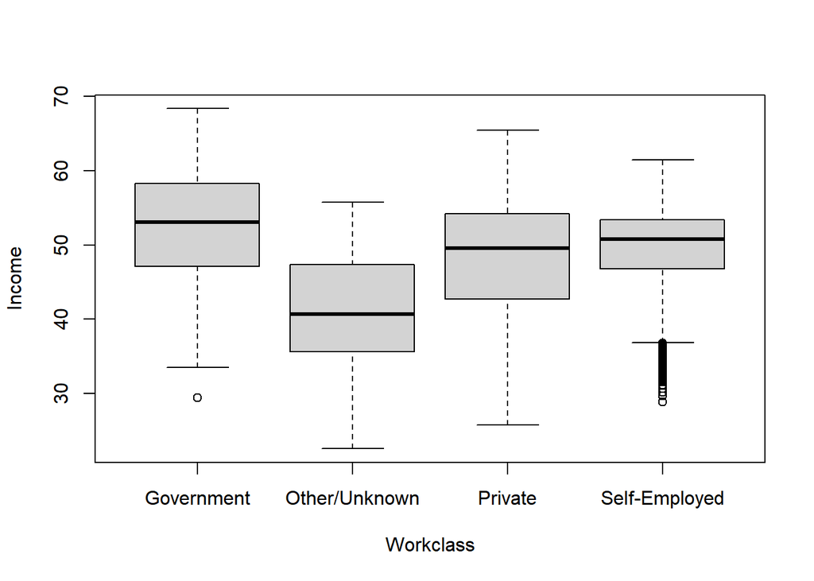

```r
boxplot(adult$income~adult$workclass, ylab = "Income", xlab = "Workclass")
```

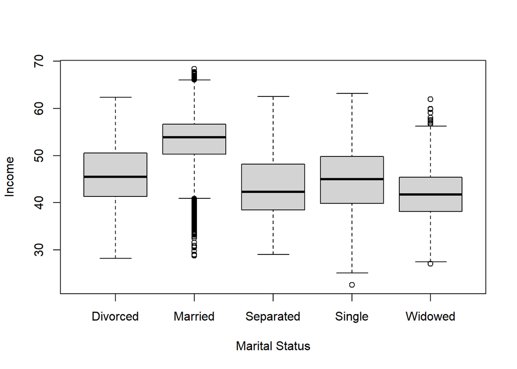

```r
boxplot(adult$income~adult$marital_status, ylab = "Income", xlab = "Marital Status")
```

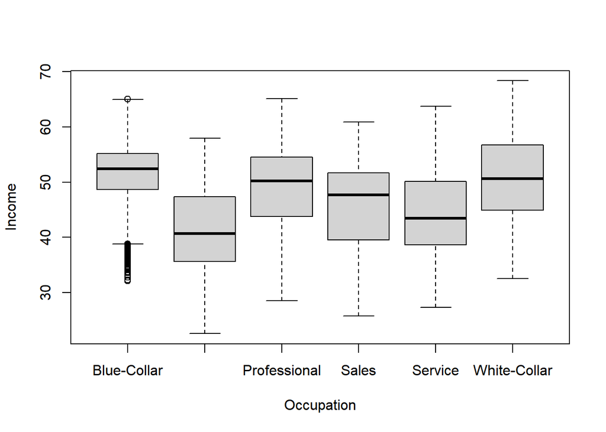

```r
boxplot(adult$income~adult$occupation, ylab = "Income", xlab = "Occupation")
```

### 2.2.2 Interesa visualizar también las variables age, hours_per_week y education_num.

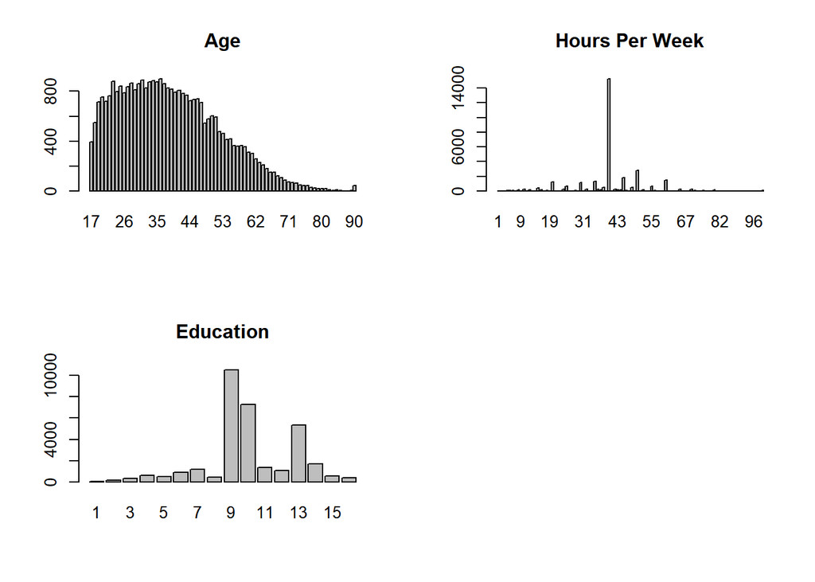

```r
par(mfrow=c(2,2))
barplot(table(adult$age), main = "Age")
barplot(table(adult$hours_per_week), main = "Hours Per Week")
barplot(table(adult$education_num), main = "Education")
```

### 2.2.3 Interpreta los gráficos brevemente. Aprovecha que las últimas variables son continuas para interpretar su tendencia.

# 3 Estadística inferencial

## 3.1 Contrastes de hipótesis

Nos interesamos ahora por las potenciales diferencias en el salario de los individuos para diferentes grupos, en particular, las mujeres y los hombres, y los grupos raciales blanco y negro.

Para contrastar las hipótesis, se divide el dataset por el género.

```r
adult.male    <- adult[adult$gender == "Male",]
adult.female  <- adult[adult$gender == "Female",]
```

Y luego por la raza `White` y `Black`.

```r
adult.white <- adult[adult$race == "White",]
adult.black <- adult[adult$race == "Black",]
```

### 3.1.1 Hipótesis nula y alternativa (por el género y por el caso racial)

Hipótesis por género:

La hipótesis nula es que no hay diferencia entre los salarios de los hombres y las mujeres. La hipótesis alternativa es que el salario de los hombres es mayor que el de las mujeres. Si $\mu_m$ se refiere al salario medio de los hombres y $\mu_f$ al salario medio de las mujeres, las hipótesis nula y alternativa son:

$$H_0: \mu_m = \mu_f\\
H_1: \mu_m > \mu_f\\$$
Hipótesis por raza:

La La hipótesis nula es que no hay diferencia entre los salarios de raza `White` y la raza `Black`.

$$H_0: \mu_w = \mu_b\\
H_1: \mu_w > \mu_b\\$$
### Justificación del test a aplicar (por el género y por el caso racial)

Se asume que la muestra sigue una distribución normal. Es un contraste de dos muestras unilateral, no se conocer la varianza de las poblaciones, por lo que, se va a realizar un test de homoscedasticidad para comprobar si son o no iguales las varianzas de las poblaciones.

Por género:

```r
var.test(adult.male$income, adult.female$income)
```

```
##
##  F test to compare two variances
##
## data:  adult.male$income and adult.female$income
## F = 1.331, num df = 21788, denom df = 10770, p-value < 2.2e-16
## alternative hypothesis: true ratio of variances is not equal to 1
## 95 percent confidence interval:
##  1.288172 1.375099
## sample estimates:
## ratio of variances
##           1.331048
```

Por raza:

```r
var.test(adult.white$income, adult.black$income)
```

```
##
##  F test to compare two variances
##
## data:  adult.white$income and adult.black$income
## F = 2.1516, num df = 27814, denom df = 3123, p-value < 2.2e-16
## alternative hypothesis: true ratio of variances is not equal to 1
## 95 percent confidence interval:
##  2.040794 2.265905
## sample estimates:
## ratio of variances
##           2.151597
```

### 3.1.2 Aplicación, interpretación y comprobación del test (por el género y por el caso racial)

A continuación, se establece la ecuación de la Varianza Conjunta en código R:

```r
sd_s = function(x1, x2){
  n_1 = length(x1)
  n_2 = length(x2)
  s_1 = sd(x1)
  s_2 = sd(x2)
  return (sqrt(((n_1 -1) * (s_1^2) + (n_2 - 1) * s_2^2)/(n_1 + n_2 -2)))
}
```

A continuación, se establece la ecuación de las Pruebas de Medias de dos Muestras σ Disconocidas en código R:

```r
t_obs = function(x1, x2){
  s_p = sd_s(x1, x2)

  n_1 = length(x1)
  n_2 = length(x2)
  x1_mean = mean(x1)
  x2_mean = mean(x2)

  return ((x1_mean - x2_mean)/(s_p*sqrt((1/n_1)+(1/n_2))))

}
```

Por género:

```r
alfa = 0.05
n_1 <- length(adult.male$income)
n_2 <- length(adult.female$income)

L <- qt(p=alfa/2, df=(n_1+n_2-2))
U <- qt(p=1-alfa/2, df=(n_1+n_2-2))
t_o = t_obs(adult.male$income, adult.female$income)

c(t_o, L, U)
```

```
## [1] 184.991710  -1.960037   1.960037
```

El estadístico t de 184.99 está fuera del rango [-1.960037, 1.960037], está fuera de la zona de aceptación de la hipótesis nula. Se concluye que los hombres cobran más que las mujeres.

Por raza:

```r
alfa = 0.05
n_1 <- length(adult.white$income)
n_2 <- length(adult.black$income)

L <- qt(p=alfa/2, df=(n_1+n_2-2))
U <- qt(p=1-alfa/2, df=(n_1+n_2-2))
t_o = t_obs(adult.white$income, adult.black$income)

c(t_o, L, U)
```

```
## [1] 52.541247 -1.960041  1.960041
```

El estadístico t de 52.54 está fuera del rango [-1.960041, 1.960041]. Se concluye que las personas de raza blanca tienen salarios más altos que los de raza negra.

# 4 Modelo de regresión lineal

## 4.1 Estimación de modelos

Estima un modelo de regresión lineal múltiple que tenga como variables explicativas: `age`, `education_num`, `hours_per_week` y `gender`, y como variable dependiente el `Income`.

```r
lm.test1 <- lm(formula = income~age+education_num+hours_per_week+gender, data = adult)
lm.test1
```

```
##
## Call:
## lm(formula = income ~ age + education_num + hours_per_week +
##     gender, data = adult)
##
## Coefficients:
##    (Intercept)             age   education_num  hours_per_week      genderMale
##       31.31578         0.08251         0.44682         0.07383        10.10840
```

Genera un segundo modelo pero esta vez añadiendo la variable `race`.

```r
lm.test2 <- lm(formula = income~age+education_num+hours_per_week+gender+race, data = adult)
lm.test2
```

```
##
## Call:
## lm(formula = income ~ age + education_num + hours_per_week +
##     gender + race, data = adult)
##
## Coefficients:
##            (Intercept)                     age           education_num
##               26.18331                 0.07825                 0.41904
##         hours_per_week              genderMale  raceAsian-Pac-Islander
##                0.07127                 9.78094                -0.21452
##              raceBlack               raceOther               raceWhite
##                2.38232                -3.56267                 6.68149
```

## 4.2 Interpretación de los modelos

### 4.2.1 Valora la significación de las variables explicativas.

Se realizará el contrastes de hipótesis para así poder detectar cuáles son las variables realmente significativas.

De los modelo obtenidos anteriores, nos interesa saber si un coeficiente $\beta_i$ es igual a cero, ya que esto querría decir que la variable $X_i$ correspondiente no figura en el modelo de regresión, y por lo tanto, no es una variable explocativa del comportamiento de la variable `Income`.

Se aplicarán los siguiente criterios de aceptación o rechazo de las hipótesis.

- Hipótesis nula: $H_0: \beta_i = 0$ (la variable $X_j$ no es explicativa).
- Hipótesis alternativa: $H_1: \beta_i \neq 0$

entonces,

- Si $p \le \alpha$, se rechaza la hipótesis nula $H_0$.
- Si $p > \alpha$, no se rechaza la hipótesis nula $H_0$.

Primero se evalúa el siguiente modelo:

$$Income = 31.31 + 0.082\cdot age + 0.44\cdot education_num + 0.07 \cdot hours_per_week + 10.10 \cdot genderMale$$

```r
summary(lm.test1)
```

```
##
## Call:
## lm(formula = income ~ age + education_num + hours_per_week +
##     gender, data = adult)
##
## Residuals:
##      Min       1Q   Median       3Q      Max
## -21.4319  -2.7990   0.2859   3.1140  17.0719
##
## Coefficients:
##                 Estimate Std. Error t value Pr(>|t|)
## (Intercept)    31.315777   0.139088  225.15   <2e-16 ***
## age             0.082515   0.001858   44.41   <2e-16 ***
## education_num   0.446817   0.009913   45.07   <2e-16 ***
## hours_per_week  0.073834   0.002123   34.77   <2e-16 ***
## genderMale     10.108404   0.055211  183.09   <2e-16 ***
## ---
## Signif. codes:  0 '***' 0.001 '**' 0.01 '*' 0.05 '.' 0.1 ' ' 1
##
## Residual standard error: 4.548 on 32555 degrees of freedom
## Multiple R-squared:  0.5892, Adjusted R-squared:  0.5891
## F-statistic: 1.167e+04 on 4 and 32555 DF,  p-value: < 2.2e-16
```

Dado que todos los valores de `p-value` (<2e-16), son menores al valor de significancia (0.05), se rechaza la hipótesis nula, y se acepta la alternativa. Las variables `age`, `education_num`, `hours_per_week` y `genderMale` si explican la variable `Income`.

Pasamos a evaluar el siguiente modelo, donde se agregó la variable `race`.

$$Income = 26.18 + 0.078\cdot age + 0.41 \cdot education_num + 0.071 \cdot hours_per_week + 9.78 \cdot genderMale -0.21 \cdot Asian-Pac-Islander + 2.38 \cdot Black - 3.56 \cdot Other + 6.68 \cdot White$$

```r
summary(lm.test2)
```

```
##
## Call:
## lm(formula = income ~ age + education_num + hours_per_week +
##     gender + race, data = adult)
##
## Residuals:
##     Min      1Q  Median      3Q     Max
## -15.264  -2.817   0.008   2.775  16.073
##
## Coefficients:
##                         Estimate Std. Error t value Pr(>|t|)
## (Intercept)            26.183312   0.260285 100.595   <2e-16 ***
## age                     0.078247   0.001673  46.768   <2e-16 ***
## education_num           0.419036   0.008971  46.710   <2e-16 ***
## hours_per_week          0.071274   0.001911  37.301   <2e-16 ***
## genderMale              9.780936   0.049976 195.712   <2e-16 ***
## raceAsian-Pac-Islander -0.214519   0.264932  -0.810    0.418
## raceBlack               2.382315   0.243405   9.787   <2e-16 ***
## raceOther              -3.562672   0.340136 -10.474   <2e-16 ***
## raceWhite               6.681488   0.233491  28.616   <2e-16 ***
## ---
## Signif. codes:  0 '***' 0.001 '**' 0.01 '*' 0.05 '.' 0.1 ' ' 1
##
## Residual standard error: 4.092 on 32551 degrees of freedom
## Multiple R-squared:  0.6674, Adjusted R-squared:  0.6674
## F-statistic:  8166 on 8 and 32551 DF,  p-value: < 2.2e-16
```

La variable `race Asian-Pac-Islander` tiene un p-value de 0.418 que es mayor al valor de significancia. Por lo tanto, se acepta la hipótesis nula. `race Asian-Pac-Islander` no explica la variable `Income`, entonces podemos eliminarla del modelo.

*¿La inclusión de la variable race ha supuesto una mejora del segundo modelo respecto al primero?*

El modelo sin la variable `race` tiene un $R^2 = 0.5892$, y con la variable `race` tiene un `R^2 = 0.6674`, por lo que si mejora el modelo.

### 4.2.2 Análisis de residuos

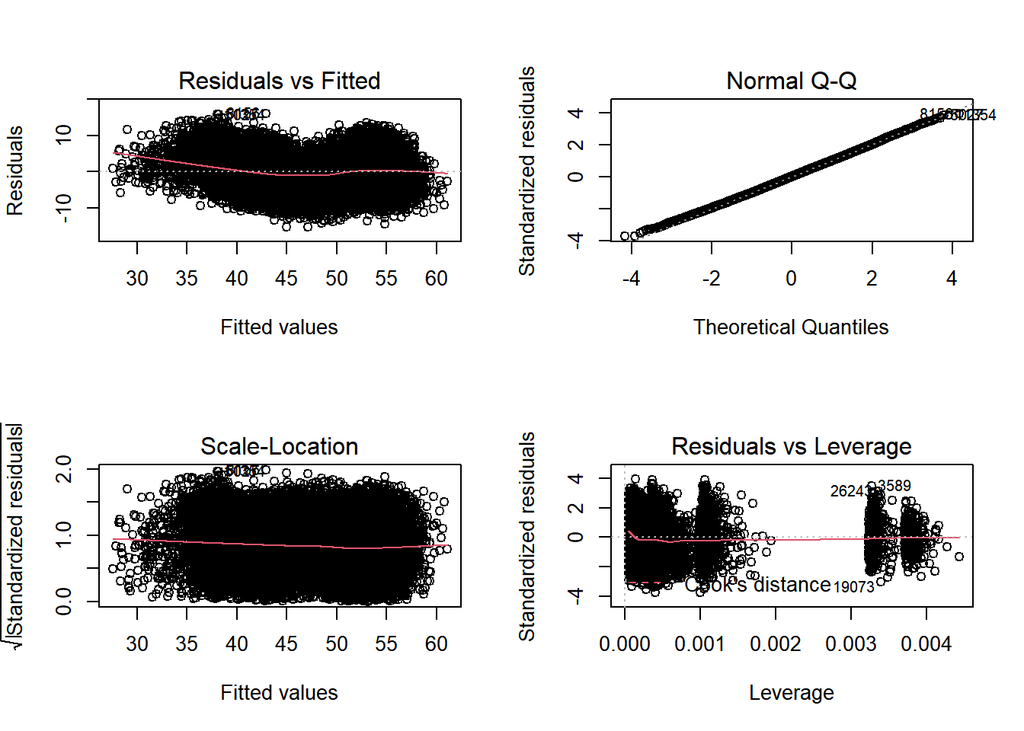

```r
par(mfrow = c(2, 2))
plot(lm.test2)
```

No observamos ningún tipo de estructura organizada de los residuos que nos haga pensar en una falta de linealidad del modelo. Tampoco observamos ningún dato atípico.

### 4.2.3 Predicción

```r
data.test = data.frame(age=24, education_num=4, hours_per_week=40, gender="Female",race="Black")
predict(lm.test2, data.test, level = 0.95, type = "response")
```

```
##        1
## 34.97064
```

El valor predicho del `Income` sería: 34.97.

# 5 Regressión logística

## 5.1 Generación de los conjuntos de entrenamiento y de test

Para dividir el dataset se utiliza la función `sample.split` del paquete `caTools`.

```r
if(!require(caTools)){
    install.packages('caTools')
  library(caTools)
}
```

Se toma el 80% de los datos como conjunto de entrenamiento, y el 20% restante como conjunto de prueba:

```r
set.seed(1234)
split <- sample.split(adult$Less50, SplitRatio = 0.80)
# Dataset de entrenamiento
training_set <- subset(adult, split == TRUE)
# Dataset de prueba
test_set <- subset(adult, split == FALSE)

cols = c("age", "workclass", "education_num", "marital_status", "occupation", "race", "gender", "hours_per_week")

testX <- test_set[, cols]
testY <- test_set[, "Less50"]

list('dataset de entrenamiento'=nrow(training_set), "dataset de prueba"=nrow(test_set))
```

```
## $`dataset de entrenamiento`
## [1] 26048
##
## $`dataset de prueba`
## [1] 6512
```

## 5.2 Modelo predictivo

A continuación, se establece el modelo:

```r
model.logist = glm(formula = Less50~gender+race+age+workclass+education_num+marital_status+occupation+hours_per_week, family = binomial(link = "logit"), data = training_set)

summary(model.logist)
```

```
##
## Call:
## glm(formula = Less50 ~ gender + race + age + workclass + education_num +
##     marital_status + occupation + hours_per_week, family = binomial(link = "logit"),
##     data = training_set)
##
## Deviance Residuals:
##     Min       1Q   Median       3Q      Max
## -4.4421  -0.1851   0.0003   0.0823   3.1446
##
## Coefficients:
##                          Estimate Std. Error z value Pr(>|z|)
## (Intercept)             15.571327   0.516816  30.129  < 2e-16 ***
## genderMale              -8.444127   0.158565 -53.253  < 2e-16 ***
## raceAsian-Pac-Islander   0.256070   0.467451   0.548  0.58383
## raceBlack               -1.376940   0.444398  -3.098  0.00195 **
## raceOther                2.382026   1.201216   1.983  0.04737 *
## raceWhite               -7.722680   0.440603 -17.528  < 2e-16 ***
## age                     -0.025706   0.002490 -10.324  < 2e-16 ***
## workclassOther/Unknown   5.917501   0.907726   6.519 7.08e-11 ***
## workclassPrivate         3.438660   0.118518  29.014  < 2e-16 ***
## workclassSelf-Employed   5.993956   0.151452  39.577  < 2e-16 ***
## education_num           -0.286147   0.012341 -23.187  < 2e-16 ***
## marital_statusMarried   -2.687132   0.092918 -28.919  < 2e-16 ***
## marital_statusSeparated  0.914356   0.182010   5.024 5.07e-07 ***
## marital_statusSingle     0.815177   0.093471   8.721  < 2e-16 ***
## marital_statusWidowed    0.099082   0.234623   0.422  0.67280
## occupationOther/Unknown  2.789809   0.905168   3.082  0.00206 **
## occupationProfessional   1.699450   0.106970  15.887  < 2e-16 ***
## occupationSales          2.670989   0.091461  29.204  < 2e-16 ***
## occupationService        2.571946   0.091731  28.038  < 2e-16 ***
## occupationWhite-Collar  -1.750835   0.111683 -15.677  < 2e-16 ***
## hours_per_week          -0.025559   0.002248 -11.369  < 2e-16 ***
## ---
## Signif. codes:  0 '***' 0.001 '**' 0.01 '*' 0.05 '.' 0.1 ' ' 1
##
## (Dispersion parameter for binomial family taken to be 1)
##
##     Null deviance: 36090.1  on 26047  degrees of freedom
## Residual deviance:  9265.4  on 26027  degrees of freedom
## AIC: 9307.4
##
## Number of Fisher Scoring iterations: 8
```

## 5.4 Matriz de confusión

Una vez que tenemos el modelo, podemos comprobar su calidad prediciendo la clase para los datos de prueba que Se ha reservado en las secciones anteriores.

```r
predicted_model <- predict(model.logist, testX, type = "response")

predict_less50 <- ifelse(predicted_model >= 0.50, 1, 0)
precision <- 100*sum(predict_less50 == testY) / length(predicted_model)

print(sprintf("La precisión del modelo es: %.4f %%",precision))
```

```
## [1] "La precisión del modelo es: 92.1990 %"
```

```r
table(testY, predict_less50)
```

```
##      predict_less50
## testY    0    1
##     0 2950  215
##     1  293 3054
```

## 5.5 Predicción

**¿Con qué probabilidad el salario de un individuo será menor a 50k€ para un hombre blanco de 20 años de edad, autónomo (self-employed), con 3 años de estudios, soltero, trabajando en el sector profesional, y ¿trabajando actualmente unas 25 horas semanales?**

```r
data.test = data.frame(age = 20, workclass="Self-Employed", race="White", education_num=3, marital_status="Single", occupation="Professional", hours_per_week=25, gender="Male")

predict(model.logist, data.test, type = "response")
```

```
##         1
## 0.9972723
```

La probabilidad es del 99% de que el salario sea menor a 50k€.

**¿Con qué probabilidad el salario de un individuo será menor a 50k€ para un hombre negro de 60 años de edad, con trabajo gubernamental, con 15 años de estudios, casado, trabajando como ‘white-collar’, y ¿trabajando actualmente unas 35 horas semanales?**

```r
data.test = data.frame(age = 60, workclass="Government", race="Black", education_num=15, marital_status="Married", occupation="White-Collar", hours_per_week=35, gender="Male")

predict(model.logist, data.test, type = "response")
```

```
##          1
## 0.00442146
```

# 6 Análisis de la varianza (ANOVA) de un factor

## 6.1 Visualización

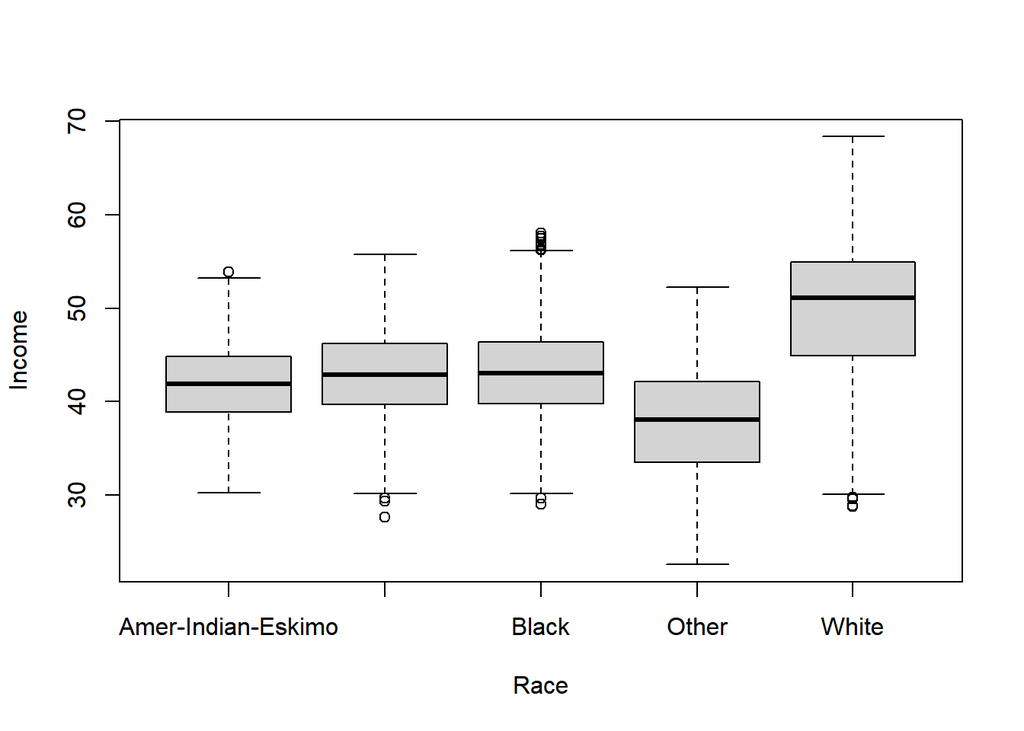

```r
boxplot(adult$income~adult$race, ylab = "Income", xlab = "Race")
```

Observamos, que La raza “White” tiene una salario más alto. En cambio, las razas “Amer-Indian-Eskimo”, “Asian-Pac-Islander” y “Black” parecen que tienen el mismo salario.

Con el fin de evaluar si existen diferencias significativas de salario entre los diferentes grupos raciales, se realizará el modelo ANOVA.

## 6.2 Modelo ANOVA

### 6.2.1 Formula el modelo

$$\hat{\sigma}^2 = \sum_{i=1}^g \sum_{j=1}^{ni} (y_{ij} - \bar{y})^2$$

### 6.2.2 Indica las hipótesis nula y alternativa

Para conocer si existen diferencias significativas entre grupos raciales, se plantea las siguientes hipótesis nulas y alternativas.

$$H_0: \alpha_{White} = \alpha_{Black}= \alpha_{Amer-Indian-Eskimo} = \alpha_{Asian-Pac-Islander} = \alpha_{Other} \\
H_1: \alpha_{White} \neq \alpha_{Black} \neq \alpha_{Amer-Indian-Eskimo} \neq \alpha_{Asian-Pac-Islander} \neq \alpha_{Other} \\$$
Aceptar $H_0$ implica que el factor no es significativo, no existen diferencias entre los salarios; por lo contrario, aceptar $H_1$ implica que el factor es significativo.

### 6.2.3 Estima la signifcación del factor grupo racial

```r
results <- lm(income~race, data = adult)
taov    <- anova(results)
taov
```

```
## Analysis of Variance Table
##
## Response: income
##              Df  Sum Sq Mean Sq F value    Pr(>F)
## race          4  211909   52977  1208.4 < 2.2e-16 ***
## Residuals 32555 1427206      44
## ---
## Signif. codes:  0 '***' 0.001 '**' 0.01 '*' 0.05 '.' 0.1 ' ' 1
```

### 6.2.4 Estima los efectos de los niveles de factor

Obtenemos un p-valor inferior a un nivel de significación del 5 %. Por lo tanto, aceptamos la hipótesis alternativa y concluimos que el factor es significativo. Es decir, el salario entre grupos raciales es significativamente diferente entre razas.

### 6.2.5 Realiza los contrastes dos-a-dos

```r
if(!require("agricolae")) install.packages("agricolae")
library(agricolae)

model <- aov(income ~ race, data = adult)
out<- HSD.test(model, "race")
out
```

```
## $statistics
##    MSerror    Df     Mean       CV
##   43.83985 32555 48.75367 13.58086
##
## $parameters
##    test name.t ntr StudentizedRange alpha
##   Tukey   race   5         3.857656  0.05
##
## $means
##                      income      std     r   Min   Max     Q25   Q50   Q75
## Amer-Indian-Eskimo 41.88682 4.498709   311 30.23 53.92 38.8900 41.93 44.81
## Asian-Pac-Islander 42.89898 4.805233  1039 27.61 55.77 39.6550 42.90 46.19
## Black              43.14683 4.694985  3124 28.97 58.07 39.7675 43.05 46.35
## Other              37.60339 5.766821   271 22.54 52.29 33.5250 38.05 42.13
## White              49.78750 6.886755 27815 28.73 68.37 44.8900 51.07 54.92
##
## $comparison
## NULL
##
## $groups
##                      income groups
## White              49.78750      a
## Black              43.14683      b
## Asian-Pac-Islander 42.89898     bc
## Amer-Indian-Eskimo 41.88682      c
## Other              37.60339      d
##
## attr(,"class")
## [1] "group"
```

### 6.2.6 Adecuación del modelo

#### 6.2.6.1 Homocedasticidad de los residuos

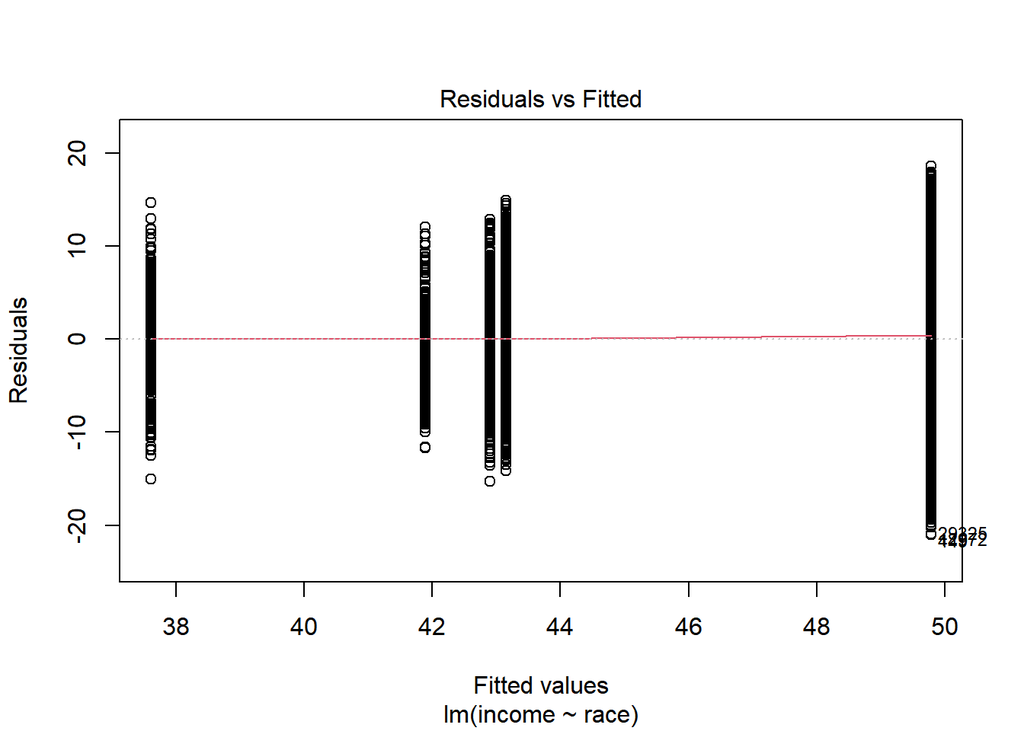

```r
plot(results, which = 1)
```

En la gráfica se observa un efecto de embudo en la disposición de los residuos del modelo. Para probar la homogeneidad de las varianzas se realiza la siguiente función:

```r
# library(car)
# leveneTest(adult$income, adult$race)
bartlett.test(income~race,data=adult)
```

```
##
##  Bartlett test of homogeneity of variances
##
## data:  income by race
## Bartlett's K-squared = 938.54, df = 4, p-value < 2.2e-16
```

Se observa el p-value, se rechaza la hipótesis nula de homogeneidad y aceptamos que las varianzas con desiguales.

#### 6.2.6.2 Normalidad de los residuos

Para contrastar la normalidad de los residuos utilizamos le test de Shapiro-Wilk.

```r
shapiro.test(residuals(results)[0:5000])
```

```
##
##  Shapiro-Wilk normality test
##
## data:  residuals(results)[0:5000]
## W = 0.9784, p-value < 2.2e-16
```

Se observa que el valor de p-value es menor al valor de significancia, por lo que rechazamos la hitesis nula, y aceptamos la alternativa de qye no sigue una distribución normal.

# 7 ANOVA multifactorial

```r
conc<-c(16.5, 14.5, 39.1, 32.0,18.4, 11.0, 26.2, 23.8,12.7, 10.8, 21.3, 28.8,14.0, 14.3, 35.8, 25.0,12.8, 10.0, 40.2, 29.3)
hormone<-rep(c("Treatment","Treatment","No Treatment","No Treatment"),5)
gender<-rep(c("Female","Male"),10)
df<-data.frame(conc,hormone,gender)
```

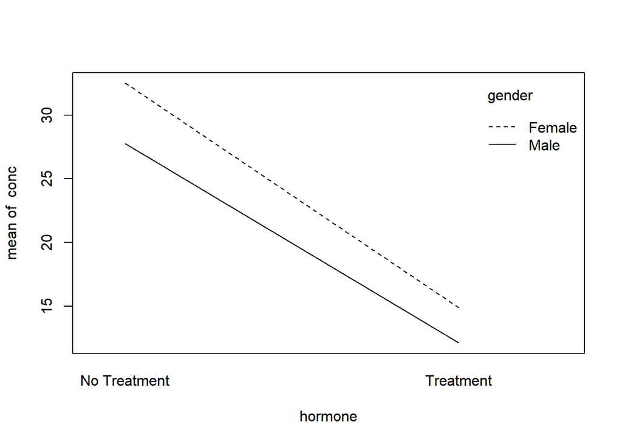

```r
interaction.plot(hormone,gender,conc)
```

```r
model <- aov(income ~ race+occupation, data = adult)
summary(model)
```

```
##                Df  Sum Sq Mean Sq F value Pr(>F)
## race            4  211909   52977    1530 <2e-16 ***
## occupation      5  300041   60008    1733 <2e-16 ***
## Residuals   32550 1127165      35
## ---
## Signif. codes:  0 '***' 0.001 '**' 0.01 '*' 0.05 '.' 0.1 ' ' 1
```

Obtenemos un p-valor inferior a un nivel de significación del 5 %. Por lo tanto, aceptamos la hipótesis alternativa y concluimos que el factor es significativo. Es decir, el salario entre grupos raciales y ocupación es significativamente diferente entre razas.